[figure not shown]

# Proyecto intermedio

Lo que haremos ahora será diseñar una aplicación que nos permita tener control sobre los miembros en un gimnasio, los ingresos, cuántos clientes al mes tenemos, entre otras cosas. De donde, específicamente, haremos:

## Librería Tkinter

La librería Tkinter es la librería de Python para crear interfaces gráficas de usuario (GUI). Te permite crear aplicaciones con ventanas, botones, cuadros de texto, menús y otros elementos interactivos. Básicamente, nos permite programar interfaces de usuario. Así:

```python
# Realizamos las importaciones necesarias
import sqlite3 as sql
import pandas as pd
import datetime as dt
from tkinter import messagebox
import tkinter as tk
from tkinter import ttk
from tkinter import filedialog
import os
```

Crearemos nuestra primera ventana

```python
# Creamos la ventana
login = tk.Tk()
# Le ponemos un nombre
login.title('Login')
# Configuramos el tamaño en pixeles
login.geometry('450x300')

# Desplegamos la interfaz
login.mainloop()
```

[figure not shown]

Lo que haremos será comenzar por realizar un sistema de login para los administradores, por lo cual deberemos de crear la base de datos correspondiente junto con la tabla, cosas que ya sabemos hacer:

```python
import sqlite3 as sql
import pandas as pd

# De una vez creamos la tabla de clientes
query_create_table = """
    CREATE TABLE clientes (
        nombre TEXT,
        edad INTEGER,
        sexo TEXT,
        telefono TEXT,
        password TEXT,
        fecha_inicio TEXT,
        fecha_fin TEXT,
        estado TEXT,
        CONTADOR INTEGER,
        fecha_nac TEXT
    );
    """

# Creamos la tabla de los admins
query_create_table_2 = """
CREATE TABLE admins (
    nombre TEXT,
    password TEXT
);
"""

con = sql.connect('clientes_db.db')
cur = con.cursor()
cur.execute(query_create_table)
cur.execute(query_create_table_2)
con.commit()
con.close()
```

[output not shown]

```python
# Realizamos la insercion de un admin
query_insert = """
INSERT INTO
    admins
VALUES
    ('admin', '123');
"""

con = sql.connect('clientes_db.db')
cur = con.cursor()
cur.execute(query_insert)
con.commit()
con.close()
```

```python
# comprobamos
con = sql.connect('clientes_db.db')
df = pd.read_sql_query("SELECT * FROM admins", con)
con.close()

df
```

[output not shown]

## ¿Qué haremos?

1. Crear la interfaz del login.
2. Montar el flujo de datos para el sistema de login de los admins.
3. Convertirlo a una función.

```python
# Creamos la ventana
login = tk.Tk()
# Le ponemos un nombre
login.title('Login')
# Configuramos el tamaño en pixeles
login.geometry('450x300')

# ttk.label() -> configuramos etiquetas visibles
l_etiqueta_titulo = ttk.Label(login, text="¡Bienvenido a mi primer App!", font=('Helvetica', 18))
# grid() -> colocamos la ubicacion donde queremos nuestra etiqueta, esto es como coordenadas de un
# plano cartesiano.
# sticky='NSWE' -> es para que la etiqueta se expanda en todas las direcciones
l_etiqueta_titulo.grid(row=0, column=1, sticky='NSWE')

# colocamos dos saltos de linea
l_etiqueta_salto_linea_1 = ttk.Label(login, text="")
l_etiqueta_salto_linea_1.grid(row=1, column=0, sticky='NSWE')
l_etiqueta_salto_linea_2 = ttk.Label(login, text="")
l_etiqueta_salto_linea_2.grid(row=2, column=0, sticky='NSWE')

l_etiqueta_password = ttk.Label(login, text="Password: ")
l_etiqueta_password.grid(row=3, column=0, sticky='NSWE')

# ttk.Entry() -> cajas de texto donde el usuario puede insertar informacion
# configuramos show='*' para que los caracteres sean ocultos
l_caja = ttk.Entry(login, show='*')
l_caja.grid(row=3, column=1, sticky='NSWE')


# Desplegamos la interfaz
login.mainloop()
```

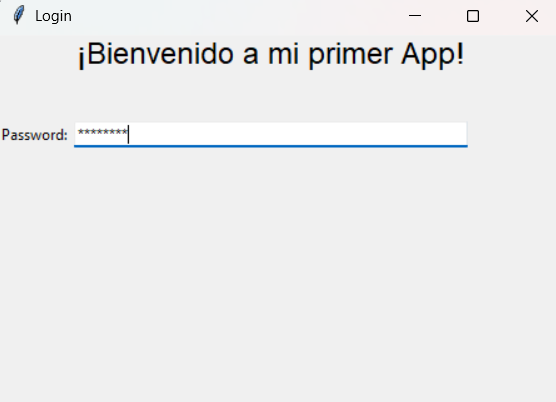

Luego, accederemos a los passwords mediante una consulta a la tabla SQL y con base en ello validaremos:

```python
# Nos traeremos los passwords de los admins paara posteriormente validar que la contraseña
# sea correcta
conn = sql.connect('clientes_db.db')
query = "SELECT * FROM admins"
df = pd.read_sql_query(query, conn)
conn.close()

# Definimos una variable global (podemos acceder a ella desde funciones) para saber si la contraseña es correcta y
# en caso de verdadero, entrar a la aplicacion
acceso = False

# Siempre que tengamos un boton, debemos de asociarle un evento (funcion)
def val_pass():
    # Accedemos a la variable global
    global acceso
    # Podemos obtener la info que el usuario ingreso en la caja de texto
    # mediante la funcion get().
    # Luego, comprobamos que la constraseña este en el listado de las contraseñas
    # de los admins
    if l_caja.get() in list(df['password'].values):
        # En caso de que la constraseña sea correcta, mostramos un mensaje de confirmacion
        # La funcion askyesno nos permite mostrar un mensaje de confirmacion y la entrada
        # es un booleano, True si el usuario confirma y False si no
        acceso = messagebox.askyesno(message="¿Desea continuar?", title="Login")
        if acceso:
            # En caso de que desee continuar, cerramos la ventana de login
            login.destroy()
    else:
        # La funcion messagebox nos pemirte mostrar mensajes de diferentes tipos al usuario
        messagebox.showerror('Error', 'Contraseña incorrecta')

# Una vez que ya tenemos la funcion o evento que disparara el boton, procedemos a
# definir, justamente, el boton con la funcion ttk.Button()
boton_val_pass = ttk.Button(login, text='Ingresar', command=val_pass)
boton_val_pass.grid(row=4, column=1, sticky='NSWE')

# Crearemos un boton para limpiar el contenido de la caja de texto del password
boton_limpiar = ttk.Button(login, text='Limpiar',
                    # En este caso el evento lo definimos mediante una lambda function
                    # sin parametro, de donde
                    # la funcion delete() borra todo lo que hay en la caja de texto
                    # desde el inicio (0) hasta el final (tk.END)
                    command=lambda: l_caja.delete(0, tk.END))
boton_limpiar.grid(row=5, column=1, sticky='NSWE')
```

Ponemos todo el código junto y tendremos finalizado nuestro sistema de login

```python
# Creamos la ventana
login = tk.Tk()
# Le ponemos un nombre
login.title('Login')
# Configuramos el tamaño
login.geometry('450x300')

# ttk.label() -> configuramos etiquetas visibles
l_etiqueta_titulo = ttk.Label(login, text="¡Bienvenido a mi primer App!", font=('Helvetica', 18))
# grid() -> colocamos la ubicacion donde queremos nuestra etiqueta, esto es como coordenadas de un
# plano cartesiano.
# sticky='NSWE' -> es para que la etiqueta se expanda en todas las direcciones
l_etiqueta_titulo.grid(row=0, column=1, sticky='NSWE')

# colocamos dos saltos de linea
l_etiqueta_salto_linea_1 = ttk.Label(login, text="")
l_etiqueta_salto_linea_1.grid(row=1, column=0, sticky='NSWE')
l_etiqueta_salto_linea_2 = ttk.Label(login, text="")
l_etiqueta_salto_linea_2.grid(row=2, column=0, sticky='NSWE')

l_etiqueta_password = ttk.Label(login, text="Password: ")
l_etiqueta_password.grid(row=3, column=0, sticky='NSWE')

# ttk.Entry() -> cajas de texto donde el usuario puede insertar informacion
# configuramos show='*' para que los caracteres sean ocultos
l_caja = ttk.Entry(login, show='*')
l_caja.grid(row=3, column=1, sticky='NSWE')


####################################################################################################
####################################################################################################

# Nos traeremos los passwords de los admins paara posteriormente validar que la contraseña
# sea correcta
conn = sql.connect('clientes_db.db')
query = "SELECT * FROM admins"
df = pd.read_sql_query(query, conn)
conn.close()

# Definimos una variable global para saber si la contraseña es correcta y
# en caso de verdadero, entrar a la aplicacion
acceso = False

# Siempre que tengamos un boton, debemos de asociarle un evento (funcion)
def val_pass():
    # Accedemos a la variable global 'r'
    global acceso
    # Podemos obtener la info que el usuario ingreso en la caja de texto
    # mediante la funcion get().
    # Luego, comprobamos que la constraseña este en el listado de las contraseñas
    # de los admins
    if l_caja.get() in list(df['password'].values):
        # En caso de que la constraseña sea correcta, mostramos un mensaje de confirmacion
        # La funcion askyesno nos permite mostrar un mensaje de confirmacion y la entrada
        # es un booleano, True si el usuario confirma y False si no
        acceso = messagebox.askyesno(message="¿Desea continuar?", title="Login")
        if acceso:
            # En caso de que desee continuar, cerramos la ventana de login
            login.destroy()
    else:
        # La funcion messagebox nos pemirte mostrar mensajes de diferentes tipos al usuario
        messagebox.showerror('Error', 'Contraseña incorrecta')

# Una vez que ya tenemos la funcion o evento que disparara el boton, procedemos a
# definir, justamente, el boton con la funcion ttk.Button()
boton_val_pass = ttk.Button(login, text='Ingresar', command=val_pass)
boton_val_pass.grid(row=4, column=1, sticky='NSWE')

#Crearemos un boton para limpiar el contenido de la caja de texto del password
boton_limpiar = ttk.Button(login, text='Limpiar',
                    # En este caso el evento lo definimos mediante una lambda function
                    # sin parametro, de donde
                    # la funcion delete() borra todo lo que hay en la caja de texto
                    # desde el inicio (0) hasta el final (tk.END)
                    command=lambda: l_caja.delete(0, tk.END))
boton_limpiar.grid(row=5, column=1, sticky='NSWE')

login.mainloop()
```

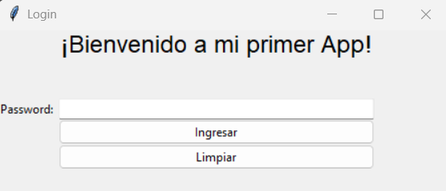

[figure not shown]

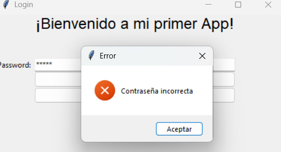

# Parte 2

Diseñaremos ahora la interfaz donde los usuarios se registraran y donde podrán acceder al gimnasio.

### 1. Configuración de un menú de opciones:

```python
# Configuracion de la ventana principal
ventana = tk.Tk()
ventana.title('App')
ventana.geometry('500x400')
estilo = ttk.Style()
estilo.theme_use("clam")

# Configuracion para un menu de opciones en la ventana principal
menu_config = tk.Menu(ventana)
ventana.config(menu = menu_config)

# Anclamos el menu
menu = tk.Menu(menu_config)

# Agregamos las opciones del menu (Son acciones, van asociadas a funciones)
menu.add_command(label = 'Ingreso')
menu.add_command(label = 'Dar de alta')

# Linea horizontal separadora
menu.add_separator()

# La funcion destroy() nos permite cerrar la ventana
menu.add_command(label = 'Salir', command=ventana.destroy)

# add_cascade() -> nos permite agregar las opciones del menu
# sin este codigo no veriamos las opciones del menu
menu_config.add_cascade(label='Menú', menu = menu)
ventana.mainloop()
```

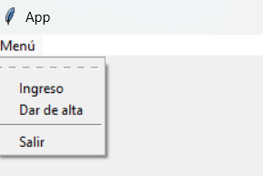

Lo que sigue es que a cada una de esas opciones le tenemos que pasar una función o evento. Comenzaremos por la función para dar de alta:

```python
def dar_alta():
    # Creamos una nueva ventana y la denominamos vc_graficar
    # como no es una ventana principal, pondremos Toplevel()
    vc_graficar = tk.Toplevel()
    vc_graficar.geometry('500x350')

    # ------------------------------------------------------

    # Etiquetas
    etiqueta_title = ttk.Label(vc_graficar, text=' REGISTROS DE NUEVOS CLIENTES\n ',
                               font=('Helvetica', 12), foreground='#000080')
    etiqueta_title.grid(row=0, column=1, sticky='NSWE')
    etiqueta_nombre = ttk.Label(vc_graficar, text='Nombre: ')
    etiqueta_nombre.grid(row=1, column=0, sticky='NSWE')
    etiqueta_edad = ttk.Label(vc_graficar, text='Edad: ')
    etiqueta_edad.grid(row=2, column=0, sticky='NSWE')
    etiqueta_sexo = ttk.Label(vc_graficar, text='Sexo: ')
    etiqueta_sexo.grid(row=3, column=0, sticky='NSWE')
    etiqueta_telefono = ttk.Label(vc_graficar, text='Telefono: ')
    etiqueta_telefono.grid(row=4, column=0, sticky='NSWE')
    etiqueta_pass = ttk.Label(vc_graficar, text='Password: ')
    etiqueta_pass.grid(row=5, column=0, sticky='NSWE')

    # ------------------------------------------------------

    # La caja de texto se mostrara en esta nueva ventana
    caja_nombre = ttk.Entry(vc_graficar, width=15)
    # Posicion de la caja de texto
    #                                                           pequenio margen
    #                                                           a la caja de texto
    n = 40
    caja_nombre.grid(row=1, column=1, sticky='NSWE', columnspan=2, padx=5, pady=5)
    caja_edad = ttk.Entry(vc_graficar, width=n)
    caja_edad.grid(row=2, column=1, sticky='NSWE', columnspan=2, padx=5, pady=5)
    # lo que hace combobox es generar una lista desplegable con los valores que le pasamos
    # en formato de una lista
    caja_sexo = ttk.Combobox(vc_graficar, state="readonly",
                             values=["M", "F", "O"])
    caja_sexo.grid(row=3, column=1, sticky='NSWE', columnspan=2, padx=5, pady=5)
    caja_telefono = ttk.Entry(vc_graficar, width=n)
    caja_telefono.grid(row=4, column=1, sticky='NSWE', columnspan=2, padx=5, pady=5)
    caja_pass = ttk.Entry(vc_graficar, width=n)
    caja_pass.grid(row=5, column=1, sticky='NSWE', columnspan=2, padx=5, pady=5)

    # ------------------------------------------------------

    # Ahora definiremos las funciones que realizaran
    # las acciones de nuestros botones.
    def subir_cliente():
        """ Lo que hace esta función es subir la informacion del cliente nuevo a nuestra base de datos
        """
        while True:
            # Realizamos el manejo de errores
            if caja_nombre.get() == '' or caja_edad.get() == '' or caja_sexo.get() == '' or caja_telefono.get() == '' or caja_pass.get() == '' or len(caja_pass.get()) != 4:
                messagebox.showerror('Error', 'Datos erróneos o longitud incorrecta del password')
                break
            try:
                int(caja_edad.get())
            except:
                messagebox.showerror('Error', 'Edad debe ser un número entero')
                break

            # info calculada: veamos en que dia estamos subiendo al cliente
            fecha_inicio = dt.datetime.now().strftime('%Y-%m-%d')
            # le damos 30 dias como su duracion de la membresia
            fecha_fin = (dt.datetime.now() + dt.timedelta(days=30)).strftime('%Y-%m-%d')
            estado = 'Activo'
            contador = 0

            # Conexion a la bbdd
            conn = sql.connect('clientes_db.db')
            c = conn.cursor()

            # info a subir
            query = f"""INSERT INTO clientes VALUES('{caja_nombre.get()}',
            {int(caja_edad.get())}, '{caja_sexo.get()}',
            '{caja_telefono.get()}', '{caja_pass.get()}',
            '{fecha_inicio}', '{fecha_fin}',
            '{estado}', {contador}, '1900-00-00')
            """

            #try:
            c.execute(query)
            #except:
                #messagebox.showerror('Error', 'Password ya existente')
                #break
            conn.commit()
            conn.close()

            # Mensaje de exito
            msj = f'Usuario {caja_nombre.get()} subido a la base de datos'
            # mostramos el mensaje en un messagebox
            messagebox.showinfo(message=msj, title='Mensaje', parent=vc_graficar)
            break

    def clean():
        """ Funcion para limpiar la informacion que se encuentra en las cajas de texto
        """
        caja_nombre.delete(0, tk.END)
        caja_edad.delete(0, tk.END)
        caja_sexo.delete(0, tk.END)
        caja_telefono.delete(0, tk.END)
        caja_pass.delete(0, tk.END)

    # Botones:
    boton_sub_cliente = ttk.Button(vc_graficar, text='Subir cliente', command=subir_cliente)
    # # Posicion de este boton
    boton_sub_cliente.grid(row=6, column=1)

    # Boton para limpiar
    boton_sub_clean = ttk.Button(vc_graficar, text='Limpiar', command=clean)
    boton_sub_clean.grid(row=8, column=1)

    # Boton para salir
    boton_sub_salir = ttk.Button(vc_graficar, text='Regresar', command=vc_graficar.destroy)
    boton_sub_salir.grid(row=9, column=1)
```

Una vez que tenemos la función para la opción de dar alta, la agregamos:

```python
# Configuracion de la ventana principal
ventana = tk.Tk()
ventana.title('App')
ventana.geometry('500x400')
estilo = ttk.Style()
estilo.theme_use("clam")

# Configuracion para un menu de opciones en la ventana principal
menu_config = tk.Menu(ventana)
ventana.config(menu = menu_config)

# Anclamos el menu
menu = tk.Menu(menu_config)

# Agregamos las opciones del menu (Son acciones, van asociadas a funciones)
menu.add_command(label = 'Ingreso')
menu.add_command(label = 'Dar de alta', command=dar_alta)

# Linea horizontal separadora
menu.add_separator()

# La funcion destroy() nos permite cerrar la ventana
menu.add_command(label = 'Salir', command=ventana.destroy)

# add_cascade() -> nos permite agregar las opciones del menu
# sin este codigo no veriamos las opciones del menu
menu_config.add_cascade(label='Menú', menu = menu)
ventana.mainloop()
```

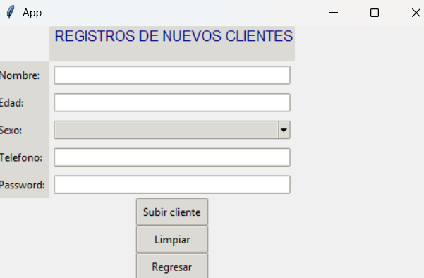

### Configurar opción de ingreso

En esta parte debemos de programar la interfaz donde los usuarios activos registren su entrada al gimnasio.

```python
def acceder():
    """
    Funcion para realizar el ingreso al gimnasio
    """

    # Ventana nueva
    ventana_m = tk.Toplevel()
    ventana_m.geometry('700x700')
    ventana_m.title('Acceso')

    # Etiquetas
    etiqueta_passw = ttk.Label(ventana_m, text='Password: ')
    etiqueta_passw.grid(row=0, column=0, sticky='NSWE')
    caja_passw = ttk.Entry(ventana_m, width=20)
    caja_passw.grid(row=0, column=1, sticky='NSWE', columnspan=2, padx=5, pady=5)

    def ingreso():
        # Obtenemos el password para realizar la consulta a la base de datos
        password = caja_passw.get()
        conn = sql.connect('clientes_db.db')
        query = f"""
        SELECT * FROM clientes WHERE password = '{password}'
        """
        # Ejecutamos y guardamos
        df = pd.read_sql_query(query, conn)
        conn.close()

        while True:
            if df.empty:
                messagebox.showerror('Error', 'Password incorrecto o no existe')
                break
            else:
                # concatenamos la informacion
                msj = f'Nombre: {df.iloc[0,0]}\
                    \n\nFecha de inicio: {df.iloc[0,5]}\
                    \n\nFecha de fin: {df.iloc[0,6]}\
                    \n\nEstado: {df.iloc[0,7]}'

                # mostramos el mensaje en una etiqueta
                etiqueta_info = ttk.Label(ventana_m, text=msj)
                etiqueta_info.grid(row=3, column=1, sticky='NSWE')
                break

    boton1 = ttk.Button(ventana_m, text='Acceder', command=ingreso)
    boton1.grid(row=1, column=1, sticky='NSWE')
```

Y ponemos marcha a conjuntar todo el código:

```python
# Configuracion de la ventana principal
ventana = tk.Tk()
ventana.title('App')
ventana.geometry('500x400')
estilo = ttk.Style()
estilo.theme_use("clam")

# Configuracion para un menu de opciones en la ventana principal
menu_config = tk.Menu(ventana)
ventana.config(menu = menu_config)

# Anclamos el menu
menu = tk.Menu(menu_config)

# Agregamos las opciones del menu (Son acciones, van asociadas a funciones)
menu.add_command(label = 'Ingreso', command=acceder)
menu.add_command(label = 'Dar de alta', command=dar_alta)

# Linea horizontal separadora
menu.add_separator()

# La funcion destroy() nos permite cerrar la ventana
menu.add_command(label = 'Salir', command=ventana.destroy)

# add_cascade() -> nos permite agregar las opciones del menu
# sin este codigo no veriamos las opciones del menu
menu_config.add_cascade(label='Menú', menu = menu)
ventana.mainloop()
```

Haremos ahora una tabla donde tendremos el registro de los ingresos al gimnasio

```python
# De una vez creamos la tabla de clientes
query_create_table = """
    CREATE TABLE clientes_ingresos (
        fecha TEXT,
        nombre TEXT,
        password TEXT
    );
    """

con = sql.connect('clientes_db.db')
cur = con.cursor()
cur.execute(query_create_table)
con.commit()
con.close()
```

Adaptamos el código de ingresos:

```python
def acceder():
    """
    Funcion para realizar el ingreso al gimnasio
    """

    # Ventana nueva
    ventana_m = tk.Toplevel()
    ventana_m.geometry('700x700')
    ventana_m.title('Acceso')

    # Etiquetas
    etiqueta_passw = ttk.Label(ventana_m, text='Password: ')
    etiqueta_passw.grid(row=0, column=0, sticky='NSWE')
    caja_passw = ttk.Entry(ventana_m, width=20)
    caja_passw.grid(row=0, column=1, sticky='NSWE', columnspan=2, padx=5, pady=5)

    def ingreso():
        # Obtenemos el password para realizar la consulta a la base de datos
        password = caja_passw.get()
        conn = sql.connect('clientes_db.db')
        query = f"""
        SELECT * FROM clientes WHERE password = '{password}'
        """
        # Ejecutamos y guardamos
        df = pd.read_sql_query(query, conn)
        conn.close()

        while True:
            if df.empty:
                messagebox.showerror('Error', 'Password incorrecto o no existe')
                break
            else:
                # concatenamos la informacion
                msj = f'Nombre: {df.iloc[0,0]}\
                    \n\nFecha de inicio: {df.iloc[0,5]}\
                    \n\nFecha de fin: {df.iloc[0,6]}\
                    \n\nEstado: {df.iloc[0,7]}'

                # mostramos el mensaje en una etiqueta
                etiqueta_info = ttk.Label(ventana_m, text=msj)
                etiqueta_info.grid(row=3, column=1, sticky='NSWE')

                ##################################################
                fecha_ingreso = dt.datetime.now().strftime('%Y-%m-%d')

                # Realizamos la insercion en la tabla de ingresos
                conn = sql.connect('clientes_db.db')
                cursor = conn.cursor()
                query_in = f"""
                INSERT INTO
                    clientes_ingresos
                VALUES('{fecha_ingreso}', '{df.iloc[0,0]}', '{password}')
                """
                # Ejecutamos y guardamos
                cursor.execute(query_in)
                conn.commit()
                conn.close()
                break

    boton1 = ttk.Button(ventana_m, text='Acceder', command=ingreso)
    boton1.grid(row=1, column=1, sticky='NSWE')
```

```python
# Configuracion de la ventana principal
ventana = tk.Tk()
ventana.title('App')
ventana.geometry('500x400')
estilo = ttk.Style()
estilo.theme_use("clam")

# Configuracion para un menu de opciones en la ventana principal
menu_config = tk.Menu(ventana)
ventana.config(menu = menu_config)

# Anclamos el menu
menu = tk.Menu(menu_config)

# Agregamos las opciones del menu (Son acciones, van asociadas a funciones)
menu.add_command(label = 'Ingreso', command=acceder)
menu.add_command(label = 'Dar de alta', command=dar_alta)

# Linea horizontal separadora
menu.add_separator()

# La funcion destroy() nos permite cerrar la ventana
menu.add_command(label = 'Salir', command=ventana.destroy)

# add_cascade() -> nos permite agregar las opciones del menu
# sin este codigo no veriamos las opciones del menu
menu_config.add_cascade(label='Menú', menu = menu)
ventana.mainloop()
```

# Consultas con SQL

```python
# Veamos los clientes que tenemos:
conn = sql.connect('clientes_db.db')
query = "SELECT * FROM clientes"
df = pd.read_sql_query(query, conn)
conn.close()

df
```

|  | nombre | edad | sexo | telefono | password | fecha_inicio | fecha_fin | estado | CONTADOR | fecha_nac |
| --- | --- | --- | --- | --- | --- | --- | --- | --- | --- | --- |
| 0 | Luis | 27 | M | 5516154492 | 1416 | 2025-03-28 | 2025-04-27 | Activo | 0 | 1900-00-00 |

```python
# Veamos los ingresos del dia
conn = sql.connect('clientes_db.db')
query = "SELECT * FROM clientes_ingresos"
df = pd.read_sql_query(query, conn)
conn.close()

df
```

|  | fecha | nombre | password |
| --- | --- | --- | --- |
| 0 | 2025-03-28 | Luis | 1416 |